# Dados Corporativos no R

Workshop UFSM

Marcelo S. Perlin

EA-UFRGS

27/08/2026

```r
classtools::setup_quarto_slides("templates")
```

# Motivação

## Documentos financeiros e pesquisa

> Demonstrações financeiras são o cerne dos estudos de finanças corporativas (Perlin et al. 2019).
- [“Accessing financial reports and corporate events with GetDFPData”](https://periodicos.fgv.br/rbfin/article/view/78654), RBFIN 2019
  - em selecionadas revistas Qualis A2/B1, em torno de 70% dos estudos de finanças entre 2013-2017 se utilizaram do economática
  - O economática, na época, só permitia operações do tipo copia e cola
  - A B3 oferece acesso público aos seus conjuntos de dados em quatro sistemas diferentes: DFP, ITR, FRE e FCA, mas com várias limitações para o acesso em larga escala.

# Os sistemas da B3 e da CVM

## DFP e FRE (Exemplo para [Petrobrás](https://sistemaswebb3-listados.b3.com.br/listedCompaniesPage/main/9512/PETR/reports?language=pt-br) )

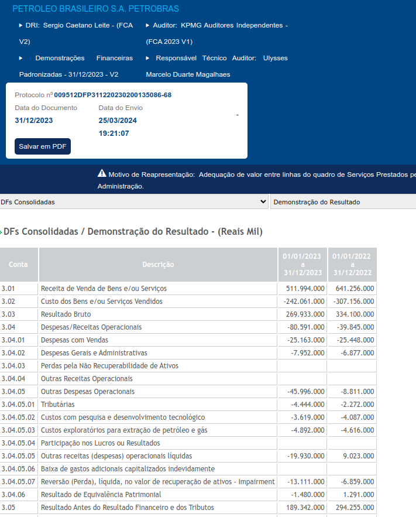

Sistema DFP

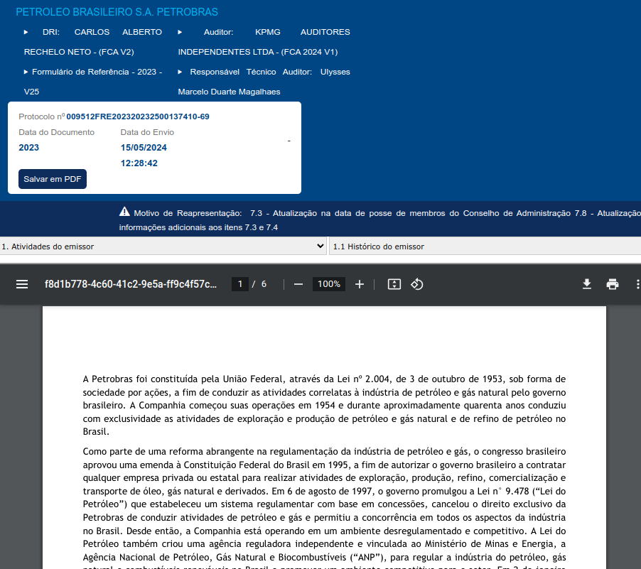

Sistema FRE

## Dados da CVM

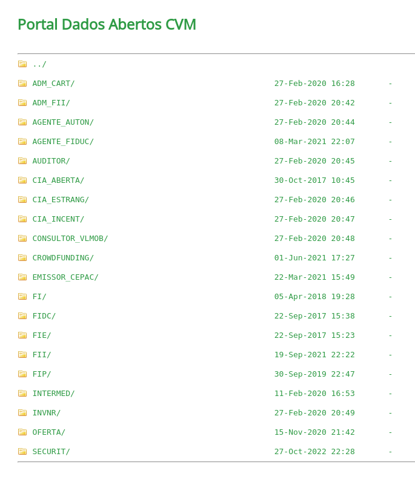

Portal de Dados CVM

[Link dados](https://dados.cvm.gov.br/dados/) | [pdf mapa](https://dados.cvm.gov.br/recursos/CentralSistemas_DadosAbertos.pdf)

# Pacotes GetDFPData2 e GetFREData

## Sobre o R

> O R é uma linguagem de programação voltada para a resolução de problemas estatísticos e para a visualização gráfica de dados.

**Autores**

Ross Ihaka e Robert Gentleman (*The University of Auckland*)

**Funcionalidade**

R é sinônimo de programação voltada à análise de dados

**Custo**

**O R é totalmente livre** e disponível em vários sistemas operacionais.

## Curiosidades e funcionalidades

- A primeira versão do pacote foi uma tentativa de atualizar slides e exercícios da graduação automaticamente (Rmarkdown/quarto)
- Inicialmente, pacote GetDFPdata agregava dados do DFP e FRE juntamente. Posteriormente, separei os pacotes entre GetDFPData2 e GetFREData

> **GetDFPData2** fornece uma interface R aberta para todas as demonstrações financeiras **anuais** distribuídas pela B3 e CVM: DRE, BP, DFC, DMPL, DVA

> **GetFREData** permite download de tabelas do sistema FRE (Formulário de Referencia): controle acionário, membros do conselho de administração, remuneração dos conselheiros, relações familiares, entre váriso outros

# Workshop

## Pacote `GetDFPData2` – Exemplo 01 (Grendene)

> Passo 01: instalar pacote

```r
install.packages("GetDFPData2")
```

> Passo 02: baixar dados das empresas disponíveis

```r
cache_folder <- "~/.cache/gdfpd2_cache"

df_info <- GetDFPData2::get_info_companies(
  cache_folder
)

df_info |>
  dplyr::glimpse()
```

```
Rows: 2,677
Columns: 47
$ CNPJ               <chr> "08.773.135/0001-00", "11.396.633/0001-87", "01.547…
$ DENOM_SOCIAL       <chr> "2W ECOBANK S.A. - EM RECUPERAÇÃO JUDICIAL", "3A CO…
$ DENOM_COMERC       <chr> "2W ECOBANK S.A.", "TRIPLO A  COMPANHIA SECURITIZAD…
$ DT_REG             <date> 2020-10-29, 2010-03-08, 1997-07-11, 1997-05-30, 19…
$ DT_CONST           <date> 2007-03-23, 2009-11-03, 1996-07-30, 1997-04-02, 19…
$ DT_CANCEL          <date> NA, 2015-12-18, NA, NA, 2006-05-30, 1998-06-17, 20…
$ MOTIVO_CANCEL      <chr> NA, "CANCELAMENTO VOLUNTÁRIO", NA, NA, "ELISÃO POR …
$ SIT_REG            <chr> "SUSPENSO(A) - DECISÃO ADM", "CANCELADA", "ATIVO", …
$ DT_INI_SIT         <date> 2026-05-19, 2015-12-18, 1997-07-11, 1997-05-30, 20…
$ CD_CVM             <dbl> 25224, 21954, 16330, 16284, 16349, 35, 16802, 13307…
$ SETOR_ATIV         <chr> "Energia Elétrica", "Securitização de Recebíveis", …
$ TP_MERC            <chr> NA, NA, NA, "BOLSA", NA, NA, NA, NA, NA, NA, NA, NA…
$ CATEG_REG          <chr> "Categoria A", "Categoria B", "Categoria B", "Categ…
```

[output cut: 34 more lines]

> Passo 03: identificar empresas

```r
df_search <- GetDFPData2::search_company("grendene")
df_search
```

```
# A tibble: 1 × 3
  CD_CVM DENOM_SOCIAL SIT_REG
   <dbl> <chr>        <chr>
1  19615 GRENDENE SA  ATIVO
```

> Passo 04: baixar os dados

```r
id_company <- 19615 # Grendene
first_year <- 2015
last_year <- 2023

# download data
l_dfp <- GetDFPData2::get_dfp_data(
  companies_cvm_codes = id_company,
  first_year = first_year,
  last_year = last_year,
  cache_folder = cache_folder
)

names(l_dfp)
```

```
[1] "DF Consolidado - Balanço Patrimonial Ativo"
[2] "DF Consolidado - Balanço Patrimonial Passivo"
[3] "DF Consolidado - Demonstração do Resultado"
[4] "DF Individual - Balanço Patrimonial Ativo"
[5] "DF Individual - Balanço Patrimonial Passivo"
[6] "DF Individual - Demonstração do Resultado"
```

> Passo 05: checar os dados

```r
bp_con <- l_dfp$`DF Consolidado - Demonstração do Resultado`

dplyr::glimpse(bp_con)
```

```
Rows: 284
Columns: 16
$ CNPJ_CIA     <chr> "89.850.341/0001-60", "89.850.341/0001-60", "89.850.341/0…
$ CD_CVM       <dbl> 19615, 19615, 19615, 19615, 19615, 19615, 19615, 19615, 1…
$ DT_REFER     <date> 2015-12-31, 2015-12-31, 2015-12-31, 2015-12-31, 2015-12-…
$ DT_INI_EXERC <date> 2015-01-01, 2015-01-01, 2015-01-01, 2015-01-01, 2015-01-…
$ DT_FIM_EXERC <date> 2015-12-31, 2015-12-31, 2015-12-31, 2015-12-31, 2015-12-…
$ DENOM_CIA    <chr> "GRENDENE S.A.", "GRENDENE S.A.", "GRENDENE S.A.", "GREND…
$ VERSAO       <dbl> 1, 1, 1, 1, 1, 1, 1, 1, 1, 1, 1, 1, 1, 1, 1, 1, 1, 1, 1, …
$ GRUPO_DFP    <chr> "DF Consolidado - Demonstração do Resultado", "DF Consoli…
$ MOEDA        <chr> "REAL", "REAL", "REAL", "REAL", "REAL", "REAL", "REAL", "…
$ ESCALA_MOEDA <chr> "MIL", "MIL", "MIL", "MIL", "MIL", "MIL", "MIL", "MIL", "…
$ ORDEM_EXERC  <chr> "ÚLTIMO", "ÚLTIMO", "ÚLTIMO", "ÚLTIMO", "ÚLTIMO", "ÚLTIMO…
$ CD_CONTA     <chr> "3.01", "3.02", "3.03", "3.04", "3.04.01", "3.04.02", "3.…
$ DS_CONTA     <chr> "Receita de Venda de Bens e/ou Serviços", "Custo dos Bens…
$ VL_CONTA     <dbl> 2202796, -1134913, 1067883, -667151, -523709, -102570, 0,…
$ COLUNA_DF    <chr> NA, NA, NA, NA, NA, NA, NA, NA, NA, NA, NA, NA, NA, NA, N…
$ source_file  <chr> "dfp_cia_aberta_DRE_con_2015.csv", "dfp_cia_aberta_DRE_co…
```

> Passo 06: analisar margem de lucro

```r
tbl_ind <- bp_con |>
  dplyr::group_by(CD_CVM, DENOM_CIA, DT_REFER) |>
  dplyr::summarise(
    margem_liq =  VL_CONTA[CD_CONTA == "3.11"]/VL_CONTA[CD_CONTA == "3.01"] # LL/Vendas
  ) |>
  dplyr::ungroup()

tbl_ind |>
  gt::gt() |>
  gt::tab_header("Margem de Lucro da Grendene") |>
  gt::fmt_percent(margem_liq)
```

Margem de Lucro da Grendene

| CD_CVM | DENOM_CIA | DT_REFER | margem_liq |
| --- | --- | --- | --- |
| 19615 | GRENDENE S.A. | 2015-12-31 | 24.48% |
| 19615 | GRENDENE S.A. | 2016-12-31 | 31.00% |
| 19615 | GRENDENE S.A. | 2017-12-31 | 29.35% |
| 19615 | GRENDENE S.A. | 2018-12-31 | 25.09% |
| 19615 | GRENDENE S.A. | 2019-12-31 | 23.90% |
| 19615 | GRENDENE S.A. | 2020-12-31 | 21.36% |
| 19615 | GRENDENE S.A. | 2021-12-31 | 25.66% |
| 19615 | GRENDENE S.A. | 2022-12-31 | 22.61% |
| 19615 | GRENDENE S.A. | 2023-12-31 | 22.92% |

```r
tbl_ind_company <- tbl_ind |>
  dplyr::filter(CD_CVM == 1023)
```

## Pacote `GetDFPData2` – Exemplo 02 (todas empresas)

> Passo 01 - baixar dados de todas empresas

```r
df_info <- GetDFPData2::get_info_companies(
  cache_folder
)

ids <- df_info$CD_CVM |>
  unique()

l_dfp <- GetDFPData2::get_dfp_data(
    companies_cvm_codes = ids,
    first_year = 2010,
    type_docs = "DRE",
    cache_folder = cache_folder
)
```

> Passo 02 - checar os dados

```r
bp_con <- l_dfp$`DF Consolidado - Demonstração do Resultado`
dplyr::glimpse(bp_con)
```

```
Rows: 221,705
Columns: 16
$ CNPJ_CIA     <chr> "00.000.000/0001-91", "00.000.000/0001-91", "00.000.000/0…
$ CD_CVM       <dbl> 1023, 1023, 1023, 1023, 1023, 1023, 1023, 1023, 1023, 102…
$ DT_REFER     <date> 2010-12-31, 2010-12-31, 2010-12-31, 2010-12-31, 2010-12-…
$ DT_INI_EXERC <date> 2010-01-01, 2010-01-01, 2010-01-01, 2010-01-01, 2010-01-…
$ DT_FIM_EXERC <date> 2010-12-31, 2010-12-31, 2010-12-31, 2010-12-31, 2010-12-…
$ DENOM_CIA    <chr> "BCO BRASIL S.A.", "BCO BRASIL S.A.", "BCO BRASIL S.A.", …
$ VERSAO       <dbl> 3, 3, 3, 3, 3, 3, 3, 3, 3, 3, 3, 3, 3, 3, 3, 3, 3, 3, 3, …
$ GRUPO_DFP    <chr> "DF Consolidado - Demonstração do Resultado", "DF Consoli…
$ MOEDA        <chr> "REAL", "REAL", "REAL", "REAL", "REAL", "REAL", "REAL", "…
$ ESCALA_MOEDA <chr> "MIL", "MIL", "MIL", "MIL", "MIL", "MIL", "MIL", "MIL", "…
$ ORDEM_EXERC  <chr> "ÚLTIMO", "ÚLTIMO", "ÚLTIMO", "ÚLTIMO", "ÚLTIMO", "ÚLTIMO…
$ CD_CONTA     <chr> "3.01", "3.01.01", "3.02", "3.02.01", "3.02.02", "3.03", …
$ DS_CONTA     <chr> "Receitas da Intermediação Financeira", "Receita de Juros…
$ VL_CONTA     <dbl> 85143206, 85143206, -50775741, -43061187, -7714554, 34367…
$ COLUNA_DF    <chr> NA, NA, NA, NA, NA, NA, NA, NA, NA, NA, NA, NA, NA, NA, N…
$ source_file  <chr> "dfp_cia_aberta_DRE_con_2010.csv", "dfp_cia_aberta_DRE_co…
```

> Passo 03 - calcular margens de lucro

```r
tbl_ind <- bp_con |>
  dplyr::group_by(CD_CVM, DENOM_CIA, DT_REFER) |>
  dplyr::reframe(
    margem_liq =  VL_CONTA[CD_CONTA == "3.11"]/VL_CONTA[CD_CONTA == "3.01"] # LL/Vendas
  ) |>
  dplyr::ungroup()

dplyr::glimpse(tbl_ind)
```

```
Rows: 6,015
Columns: 4
$ CD_CVM     <dbl> 94, 94, 94, 94, 94, 94, 94, 94, 94, 94, 94, 94, 94, 94, 94,…
$ DENOM_CIA  <chr> "PANATLANTICA S.A.", "PANATLANTICA S.A.", "PANATLANTICA S.A…
$ DT_REFER   <date> 2010-12-31, 2011-12-31, 2012-12-31, 2013-12-31, 2014-12-31…
$ margem_liq <dbl> 0.052869467, 0.036396859, 0.041271273, 0.086840074, 0.02109…
```

> Passo 01 - baixar dados da Grendene

```r
id_company <- 19615 # Grendene
first_year <- 2015
last_year <- 2022

# download data
l_fre <- GetFREData::get_fre_data2(
  first_year = first_year,
  last_year = last_year,
  cache_folder = cache_folder
)
```

> Passo 02 - checar os dados

```r
names(l_fre)
```

```
 [1] "fre_cia_aberta"
 [2] "fre_cia_aberta_administrador_membro_conselho_fiscal"
 [3] "fre_cia_aberta_ativo_imobilizado"
 [4] "fre_cia_aberta_ativo_intangivel"
 [5] "fre_cia_aberta_auditor"
 [6] "fre_cia_aberta_auditor_responsavel"
 [7] "fre_cia_aberta_capital_social"
 [8] "fre_cia_aberta_capital_social_aumento"
 [9] "fre_cia_aberta_capital_social_aumento_classe_acao"
[10] "fre_cia_aberta_capital_social_classe_acao"
[11] "fre_cia_aberta_capital_social_desdobramento"
[12] "fre_cia_aberta_capital_social_desdobramento_classe_acao"
[13] "fre_cia_aberta_capital_social_reducao"
[14] "fre_cia_aberta_capital_social_reducao_classe_acao"
[15] "fre_cia_aberta_capital_social_titulo_conversivel"
```

[output cut: 32 more lines]

> Passo 03- analisar composição atual do conselho

```r
df_boards <- l_fre$fre_cia_aberta_membro_comite
last_year <- max(df_boards$data_referencia)

df_board_current <- df_boards |>
  dplyr::filter(data_referencia == last_year)

df_board_current |>
  dplyr::select(nome,
                cpf, profissao,data_nascimento,
                data_eleicao) |>
  gt::gt() |>
  gt::tab_header(
    title = "Composição do Conselho -- GRENDENE",
    subtitle = glue::glue("Dados para {last_year}"))
```

Dados para 2022-06-30

| nome | cpf | profissao | data_nascimento | data_eleicao |
| --- | --- | --- | --- | --- |
| Alejandro G. Elsztain | 232.445.688-58 | Engenheiro Agropecuário | 1966-03-31 | 2021-11-03 |
| Isaac Selim Sutton | 047.010.738-30 | Economista | 1960-10-25 | 2021-11-03 |
| Eliane Aleixo | 783.519.367-15 | Economista | 1963-02-05 | 2021-11-03 |
| Rafael Espinola de Vasconcelos | 023.957.687-07 | Engenheiro | NA | 2021-11-03 |
| Isabella Saboya | 017.919.007-55 | Empresária | 1970-08-25 | 2021-11-03 |
| Alejandro Gustavo Casaretto | NA | Engenheiro Agrônomo | 1952-10-15 | 2021-10-27 |
| Alejandro Gustavo Casaretto | NA | Engenheiro Agrônomo | 1952-10-15 | 2021-10-27 |
| Maria Fernanda dos Santos Teixeira | 765.087.908-97 | Administradora | 1952-08-10 | 2022-02-14 |
| André José Valério | 300.848.918-40 | Contador | 1982-10-20 | 2021-08-17 |
| Silvio José Genesini Júnior | 607.689.408-34 | Engenheiro | 1952-10-27 | 2021-10-19 |

# Aprendizado

- Existe uma variedade imensa de dados públicos que podem ser usados em pesquisa
- Raspagem de dados de sites é momentânea e não-sustentável!
  - procura uma maneira oficial de coletar dados
  - evite raspar dados da B3!
- Cuidado com os dados que são raspados sem consentimento!
- O código vai evoluir, quanto mais simples, melhor..

# Próximos passos e dicas pacotes

## Próximos passos

1. Nova versão atualizada
   - revisar código
   - novo sistema de cacheamento
   - arrumar nomes das colunas
   - gestão de erros em download
   - usar dados da CVM (e não B3)
2. Olhar outros dados da CVM
3. Desenvolver pacote equivalente para dados do Edgar/SEC/USA

## Um acesso mais direto aos dados

> Anualmente, um script importa todos os dados disponíveis na B3, organiza os dados e disponibiliza no site https://msperlin.com/data/

[figure not shown]

Dataverse

## Produções resultantes

REICHERT, M. ; PERLIN, M. S. . What Drives the Release of Material Facts for Brazilian Stocks?. REVISTA BRASILEIRA DE FINANÇAS (IMPRESSO), v. 20, p. 01-15, 2022.

MASTELLA, M. ; PERLIN, MARCELO S. ; KIRCH, G. ; VANCIN, D. . Board gender diversity: performance and risk of Brazilian firms. GENDER IN MANAGEMENT (PRINT), v. ahead-of-print, p. 1-30, 2021. Citações:16|19

PERLIN, M. S.; KIRCH, G. ; MASTELLA, M. ; VANCIN, D. . O Impacto Da Titulação Acadêmica De Conselheiros E Diretores Sobre A Performance De Empresas Negociadas Na B3. BBR. BRAZILIAN BUSINESS REVIEW (EDIÇÃO EM PORTUGUÊS. ONLINE), v. 18, p. 561-584, 2021.

PERLIN, M. S.; KIRCH, G. ; VANCIN, D. . Accessing financial reports and corporate events with GetDFPData. REVISTA BRASILEIRA DE FINANÇAS: RBFIN = RBFIN: BRAZILIAN FINANCE REVIEW, v. 17, p. 85, 2019.

+38 citações do pacote em artigo publicado

## Curiosidades

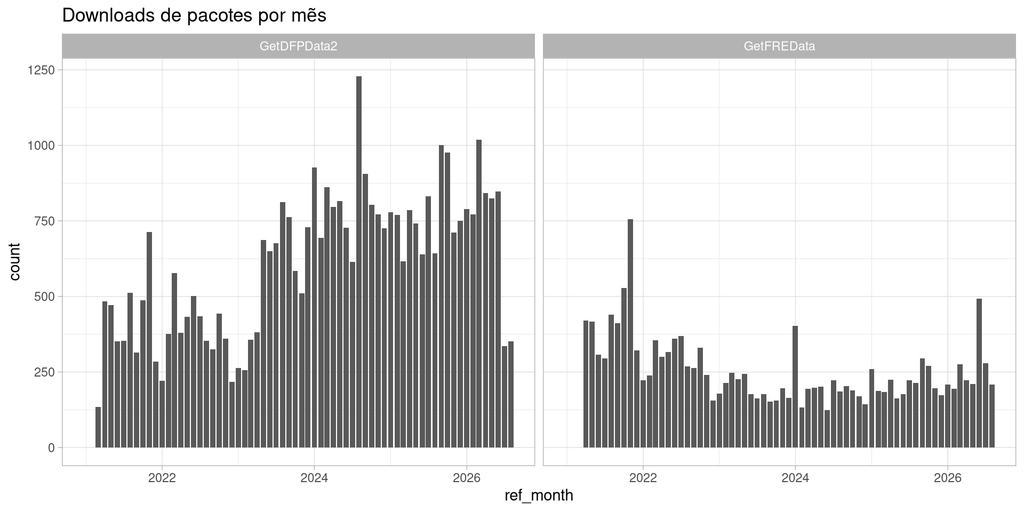

# Livros do R

## Introdução ao R – Um guia prático para iniciantes

[figure not shown]

- publicado em abril/2024
- disponível como ebook e impresso na [Amazon](https://www.amazon.com.br/dp/B0CYN25PD6)
- versão online e **integral** em https://www.msperlin.com/introR/

## Programação e Análise de Dados com o R

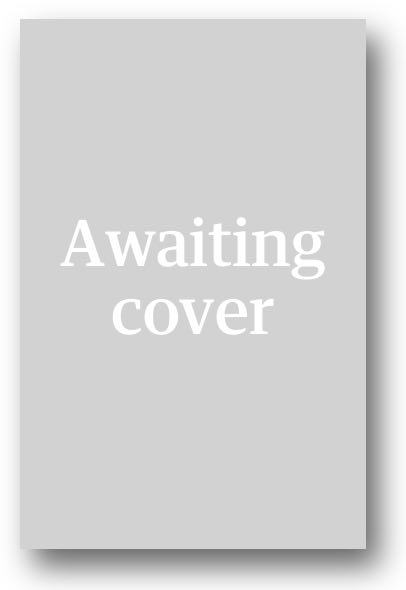

- Em desenvolvimento!
- **Provável** publicação em 2025

## Visualização de Dados com o R

[figure not shown]

- Disponível como ebook e impresso na [Amazon](https://www.amazon.com.br/dp/B0BK2V4HTB)
- Versão online em https://www.msperlin.com/vdr/

## Questões de R em Concursos Públicos

[figure not shown]

# Referências

Perlin, Marcelo S, Guilherme Kirch, and Daniel Vancin. 2019. “Accessing Financial Reports and Corporate Events with GetDFPData.” *Brazilian Review of Finance* 17 (3): 85–108.